# Inference

Confidence Interval and Hypothesis Testing

Ranadeep Daw

2024-09-03

## Lecture Outline

- Normal distribution
- Estimation
- Confidence interval
- Hypothesis testing
- p-value

# Normal Distribution

## Binomial Distribution

- Recall the coin toss example from last class. We tossed a coin $n$ times, where one toss followed a *probability distribution* as:
  $$\begin{align*}
  \mathbb{P}(X = H) = p \\
  \mathbb{P}(X = T) = 1-p \\
  \end{align*}$$
- This is an example of Binomial distribution.
- Very important for discrete or non-numeric data.
- To be revisited later, while analyzing count data.

## Plotting the Probability Distribution

- If I assign $p = 0.2$, the plot of probabilities will look like this:

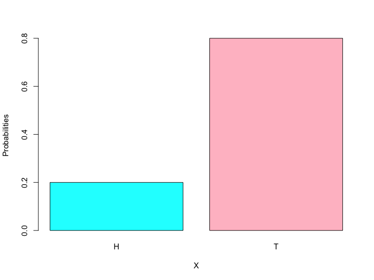

## Plotting the Probability Distribution

- If I assign $p = 0.5$, the plot of probabilities will look like this:

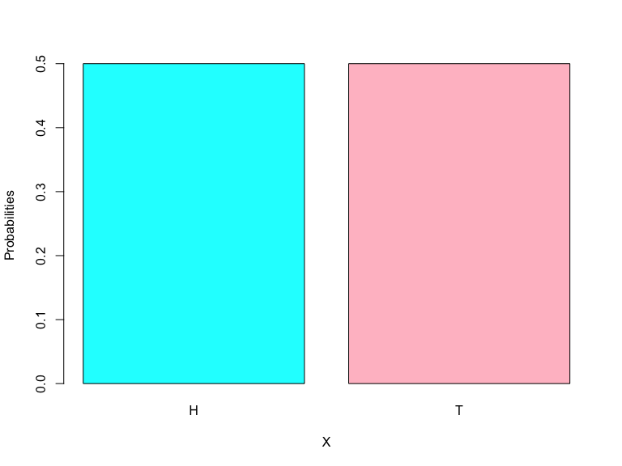

## Normal Distribution

- Normal or Gaussian distribution is another probability distribution – but for continuous data.
- The most common choice to analyze continuous data.
- We will discuss estimation, confidence interval, and hypothesis testing.
- Computation

## Normal Distribution: Definition

- Defined by two parameters: $\mu$ (mean) and $\sigma^2$ (variance).
- We write: $X \sim N(\mu, \sigma^2)$
- Probability density function:
  $$f(x; \mu,
  \sigma^2) = \frac{1}{\sqrt{2\pi \sigma^2}} \exp{ - \frac{(x -
  \mu)^2}{2\sigma^2}}$$
- *Standard* normal distribution: When $\mu$ = 0, $\sigma^2$ = 1.

## Plotting the Probability Distribution

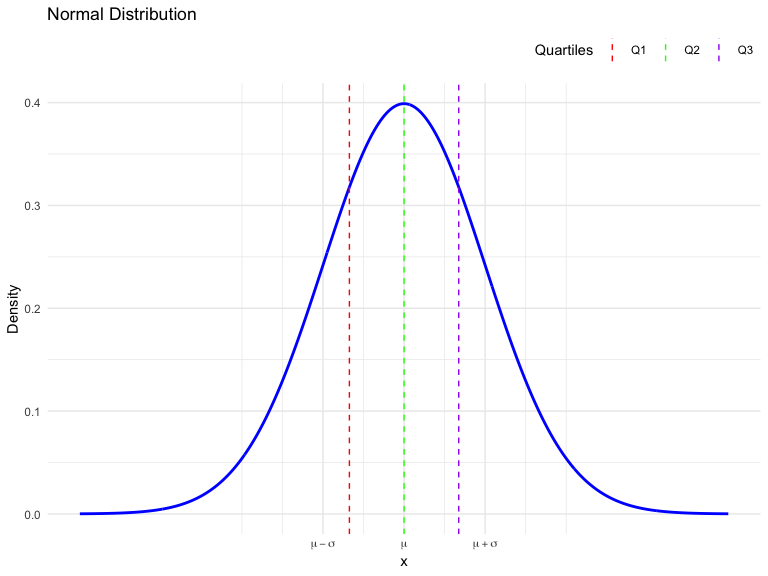

## Properties

- Mean($X$) or $\mathbb{E}(X)$ = $\mu$.
- Median($X$) = $\mu$.
- Variance($X$) or var($X$) = $\sigma^2$.
- $X$ is symmetric around the mean.
- Quartiles:
  - $Q_1 \approx \mu − 0.674 * \sigma$
  - $Q_3 \approx \mu + 0.674 * \sigma$
  - $Q_2 = ??$
  - IQR = ??

## Properties

- Mean($X$) or $\mathbb{E}(X)$ = $\mu$.
- Median($X$) = $\mu$.
- Variance($X$) or var($X$) = $\sigma^2$.
- $X$ is symmetric around the mean.
- Quartiles:
  - $Q_1 \approx \mu − 0.674 * \sigma$
  - $Q_3 \approx \mu + 0.674 * \sigma$
  - $Q_2$ = $\mu$
  - IQR $\approx$ $1.35 \sigma$

## Question

- What is the meaning of $Q_1$ here?

## Question

- What is the meaning of $Q_1$ here?
- Probability of getting data $\leq Q_1$ = $\frac{1}{4}$.

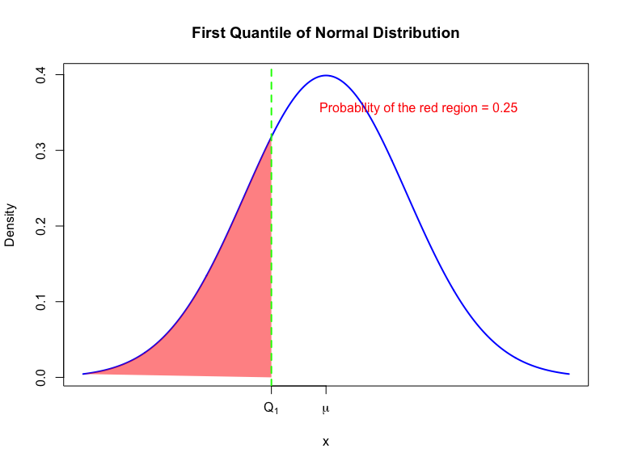

## Using Normal Distribution

- To use normal distribution in data analysis, we assume that our data is a sample from a population that follows a normal distribution.
- Recall, we almost always have a sample data, never the entire population.
- Recall, we never know parameters. Can only guess them from sample statistics.
- Use data to estimate the parameters $\mu$ and $\sigma^2$.
- Careful, nothing in real life exactly follows a statistical model.

# Estimation

## Point Estimates

- A single value of a statistic, calculated from our sample data, that serves as the best guess of an unknown parameter.
- Example:
  - Sample mean is an estimator of population mean.
  - Sample variance is an estimator of population variance.
  - You may try to research about BLUP (best linear unbiased prediction).

## Normal Distribution Estimates

- Suppose we have a continuous random variable $\mathrm{X}$; and we have realizations $\{x_1, \ldots, x_n\}$ from it.
- We assume it to be a sample from a $\mathbb{N}(\mu, \sigma^2)$ (or $X_i \sim N(\mu, \sigma^2)$).
- Estimate the parameters $\mu$ and $\sigma^2$ with their sample equivalents:
  - $\hat{\mu} = \bar{x}$ (sample mean).
  - $\hat{\sigma^2} = s^2$ (sample variance).

## Example

- Question: Assume that from the $\texttt{mtcars}$ data, the gas mileage variable is a sample from a normal distribution. What is your best estimate for it’s mean and variance?

## Example (contd.)

- Question 1: Assume that from the $\texttt{mtcars}$ data, the gas mileage variable is a sample from a normal distribution. What is your best estimate for it’s mean and variance?

```r
data("mtcars")
MPG = mtcars$mpg
mean(MPG)
```

```
## [1] 20.09062
```

```r
var(MPG)
```

```
## [1] 36.3241
```

## Example (contd.)

Question 1: Assume that from the $\texttt{mtcars}$ data, the gas mileage variable is a sample from a normal distribution. What is your best estimate for it’s mean and variance?

- I Assume that mpg $\sim N(\mu, \sigma^2)$.
- From data, the sample mean is $\bar{x} = 20.09$, $s^2 =36.32$.
- So, my estimates are:
  - $\hat{\mu} = 20.09, \hat{\sigma}^2 = 36.32$.

## Example (contd.)

- Question 2: Under the same assumption and same data, what is the estimated population median?

## Example (contd.)

- Question 2: Under the same assumption and same data, what is the estimated population median?
  - Since normal mean and median are the same, it is still $\bar{x} = \hat{\mu} = 20.09$.

# Confidence Interval

## Confidence Interval (CI)

- Even if we only have a sample of $3$ observations, we can always estimate both $\mu$ and $\sigma^2$.
- Recall the coin toss exmple. Is 6 H out of 10 decisive to suspect cheating? Is 6348 H out of 10000 decisive enough?
- But, are they any good? How confident are we?
- To analyze the reliability of the estimate, we use confidence interval.

## CI (contd.)

- A $100(1 - \alpha)\%$ CI is an interval that is expected to contain the true parameter $100(1 - \alpha)\%$ time had we have access to a large number of samples.
- Example: Set $\alpha = 0.05$. A $95\%$ CI for the population mean ($\mu$) means that, if we had 100 random samples from the population, I expect $95$ of the intervals to contain the true $\mu$.

## CI: Graphical View

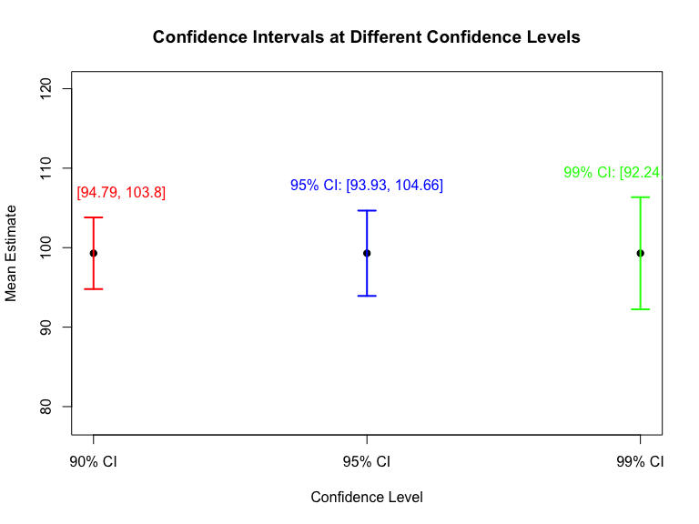

## Interval Width

- Wider interval are more likely to contain the parameter, thereby increases our confidence level $100(1 - \alpha)\%$.
- But, wider interval also introduces more uncertainty on my point estimate.
- Therefore, we want an interval as narrow as possible.
- We fix the confidence level first, typically at $95\%$ (or $\alpha = 0.05$), $90\%$, $99\%$. Then we try to narrow down the interval.

## CI for Normal Distribution

- Case 1: Known variance ($\sigma^2$).
  - Point estimate of $\mu$: $\bar{x}$.
  - $100(1-\alpha)\%$ of $\mu$ = $\bar{x} \pm z_{\alpha/2} * \frac{\sigma}{\sqrt{n}}$.
    - $\bar{x}$ is the sample mean.
    - $\sigma$ is the standard deviation.
    - $n$ is the number of observations.
    - $z_{\alpha/2}$ is the **z score**, a critical value. Same as the negative of $\frac{\alpha}{2}$-th quantile of a *standard* normal distribution.

## CI for Normal Distribution

- Case 2: Unknown variance (typical case).
- Point estimate of $\mu$: $\bar{x}$.
- Point estimate of $\sigma^2$: $s^2$.
  - $100(1-\alpha)\%$ of $\mu$ = $\bar{x} \pm t_{\alpha/2, n-1} * \frac{s}{\sqrt{n}}$.
    - $\bar{x}$ and $s^2$ are the sample mean and variance.
    - $n$ is the number of observations.
    - $t_{\alpha/2, n-1}$ is the **critical value**, same as the negative of $\alpha/2$-th quantile from a **student’s t** distribution with degrees of freedom $n-1$.

## $\texttt{R}$ syntax (Unknown Variance)

```r
t.test(vector, conf.level = 1- alpha)$conf.int
```

- Continue the last example with $\texttt{mtcars}$ data: $95\%$ CI for gas mileage (mpg).

```r
data("mtcars")
mpgs = mtcars$mpg
t.test(mpgs, conf.level = 0.95)$conf.int
```

```
## [1] 17.91768 22.26357
## attr(,"conf.level")
## [1] 0.95
```

- My $95\%$ confidence interval for $\mu$, the unknown population mean of mpg is $(17.92, 22.26)$.

## $\texttt{R}$ Example

- Let’s find the $90\%$ CI for mpg (or $\alpha$ = 0.1).

```r
data("mtcars")
mpgs = mtcars$mpg
t.test(mpgs, conf.level = 0.90)$conf.int
```

```
## [1] 18.28418 21.89707
## attr(,"conf.level")
## [1] 0.9
```

- My $90\%$ confidence interval for $\mu$, the unknown population mean of mpg is $(18.28, 21.90)$.
- Note, smaller interval compared to the earlier.

## $\texttt{R}$ Example (contd.)

- Let’s find the $99\%$ CI for mpg (or $\alpha$ = 0.01).

```r
data("mtcars")
mpgs = mtcars$mpg
t.test(mpgs, conf.level = 0.99)$conf.int
```

```
## [1] 17.16706 23.01419
## attr(,"conf.level")
## [1] 0.99
```

- My $99\%$ confidence interval for $\mu$, the unknown population mean of mpg is $(17.17, 23.01)$.
- Note, much wider interval compared to the earlier.

## Question

- Can I calculate this interval manually in $\texttt{R}$?
- You need to know two commands:
  - $\texttt{qt(<quantile>, <df>)}$: to generate the critical value for $t$-distribution with degrees of freedom $df$.
  - $\texttt{qnorm(<quantile>)}$: to generate the critical value for standard normal distribution.

## Example: Manual computation of CI (unknown case)

Example with $\texttt{mtcars}$ data: $95\%$ CI for gas mileage (mpg).

```r
data("mtcars")
n = nrow(mtcars)
mpgs = mtcars$mpg
xbar = mean(mpgs)
sample_sd = sd(mpgs)
alpha = 0.05
critical_score = qt(1 - alpha/2, df = n - 1)
lower = xbar -critical_score * sample_sd/sqrt(n)
upper = xbar +critical_score * sample_sd/sqrt(n)
c(lower, upper)
```

```
## [1] 17.91768 22.26357
```

## Example: Manual computation (known case)

```r
sigma = 6
data("mtcars")
n = nrow(mtcars)
mpgs = mtcars$mpg
xbar = mean(mpgs)
alpha = 0.05
zscore = qnorm(1 - alpha)
lower = xbar -zscore * sigma/n
upper = xbar +zscore * sigma/n
c(lower, upper)
```

```
## [1] 19.78221 20.39904
```

# Hypothesis Testing

## Hypothesis Testing : Motivation

- Recall our coin toss example.
  - 6 H out of 10 tosses: We should not be able to conclude cheating.
  - 6348 H out of 10000 tosses: We should be able to conclude cheating.
- Hypothesis testing helps quantify such decision making.

## CI vs Testing

- Take the coin toss example.
- A confidence interval will generate an interval ($p_1, p_2$), from my estimated $\hat{p}$. I expect the CI to contain the true $p$ $95\%$ of the times if I could resample the data many times.
- In hypothesis testing, one would start with a starting belief (e.g., $p=0.5$). Then try to decide if my belief is correct or not from the data.

## Definition

- A statistical method to draw conclusions or inferences about a population parameter based on sample data and statistics.

## Hypotheses

- **Hypothesis**: A claim about the unknown population parameter.
  - Example: In the coin toss example, I suspect that probability of a Head (p) = 0.6
  - Careful: Hypothesis is about population parameters; never about the sample statistics.
- We typically test two hypotheses: Null hypothesis ($H_0$) and Alternate hypothesis ($H_A$).

## Null vs Alternate

- **Null hypothesis** ($H_0$): Starting claim or belief about the population parameter.
  - It is true until you have proof that it is false.
- **Alternate hypothesis** ($H_A$): Another statement about the parameter. It is assumed to be true when we have evidence that $H_0$ is false.
  - We either reject $H_0$ (enough evidence that it’s false) or we fail to reject $H_0$. *We never accept $H_0$.*

## Graphical representation

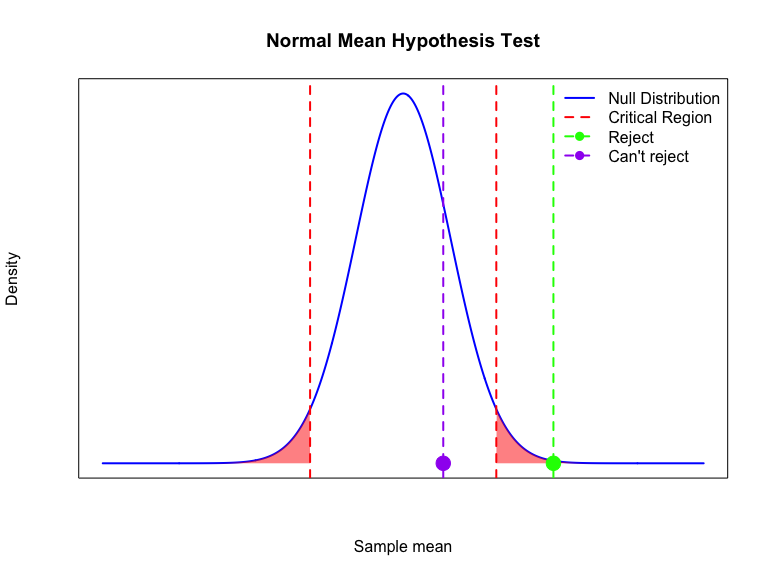

## One vs Two sided Test

- Depending on the **alternate hypothesis ($H_A$)**, a test can be one sided or two sided.
- If we want to test parameter = some value against parameter $\neq$ the value, the test is two sided.
  - e.g. $H_0$: Average score = 75 vs $H_A$: Average score $\neq$ 75.
  - Your starting belief ($H_0$) is not true if the sample average is too high or too low.

## Two-sided test

- $H_0$: $\mu$ = $m$, $H_A$: $\mu$ $\neq$ $m$.
- Evidence of false starting belief ($H_0$) is two sided: $\hat{\mu} \leq c_1$ or $\hat{\mu} \geq c_2$.

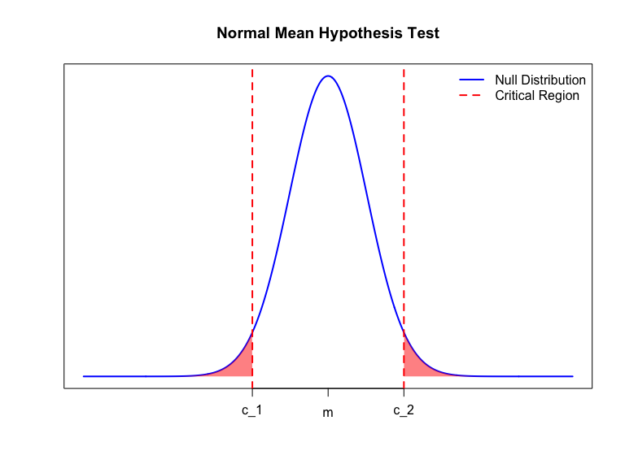

## One-sided test: Case 1

- $H_0$: $\mu$ $\leq$ (or $=$) $m$, $H_A$: $\mu$ $\geq$ $m$.
- Evidence of false starting belief ($H_0$) is one sided: $\hat{\mu} \geq c$.

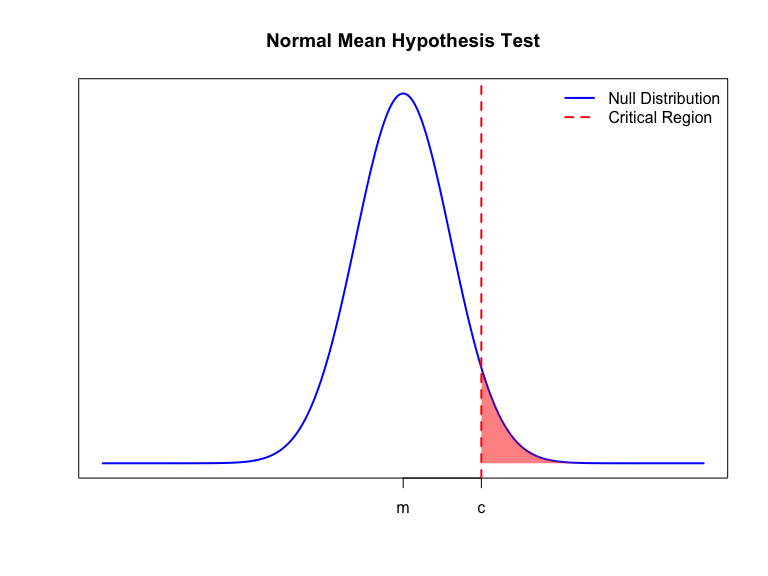

## One-sided test: Case 2

- $H_0$: $\mu$ $\geq$ (or $=$) $m$, $H_A$: $\mu$ $\leq$ $m$.
- Evidence of false starting belief ($H_0$) is one sided: $\hat{\mu} \leq c$.

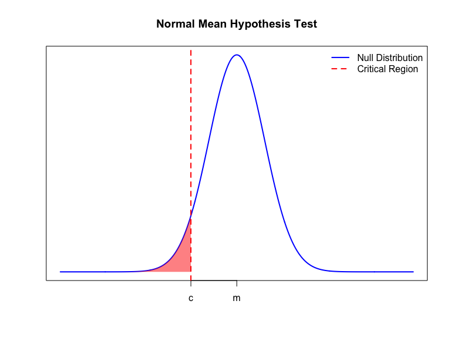

## Example 1

1. Recall the mallard duck weights example from last class. I want to test if the average weight of mallard ducks is 4kg or not.
- One or two tailed?
- $H_0$: ?
- $H_A$: ?
- How will the region with evidence of wrong $H_0$ look like?

## Example 1 (contd.)

1. Recall the mallard duck weights example from last class. I want to test if the average weight of mallard ducks is 4kg or not.
- One or two tailed? Two tailed
- $H_0$: $\mu = 4$. ($\mu$ = Population average weight).
- $H_A$: $\mu \neq 4$
- How will the region with evidence of wrong $H_0$ look like? $\hat{\mu} \leq c_1$ or $\hat{\mu} \geq c_2$.

## Example 2

2. I believe that the average old car price is Pensacola is **less than** $\$15000.00$.
- One or two tailed?
- $H_0$: ?
- $H_A$: ?
- How will the region with evidence of wrong $H_0$ look like?

## Example 2

2. I believe that the average old car price is Pensacola is less than $\$15000.00$. How can I do a hypothesis test?
- One or two tailed? One-tailed.
- $H_0$: $\mu \geq 15000.00$.
- $H_A$: $\mu \leq 15000.00$.
- How will the region with evidence of wrong $H_0$ look like? $\hat{\mu} \leq c$.

## Testing Errors

Type I and Type II Errors in Hypothesis Testing

[output not shown]

## Details of Hypothesis Testing

- Define the **significance level** $\alpha$ = $\mathbb{P}$(Type I error).
- Define $\beta$ = $\mathbb{P}$(Type II error).
- We want to minimize both, but never possible.
- We first fix $\alpha$, typical values are $0.01, 0.05, 0.10$.
- Then we try to minimize $\beta$, or maximize **Power** = $1 - \beta$.

## Revisit Example 2.

- I believe that the average old car price is Pensacola is less than $\$15000.00$.
- I am testing $H_0$: $\mu \geq 15000.00$, vs $\mu \leq 15000.00$.
  - What is a Type 1 error here?
  - What is a Type 2 error here?

## Revisit Example 2.

- I believe that the average old car price is Pensacola is less than $\$15000.00$.
- I am testing $H_0$: $\mu \geq 15000.00$, vs $\mu \leq 15000.00$.
  - What is a Type 1 error here?
    - When $\mu$, the average old car price, is $\geq 15000.00$, but my hypothesis testing concludes that it is $\leq 15000.00$.
  - What is a Type 2 error here?
    - When $\mu$, the average old car price, is $\leq 15000.00$, but my hypothesis testing concludes that it is $\geq 15000.00$.

## Steps of Hypothesis Testing

- Step 1: State your hypothesis.
- Step 2: Fix significance level $\alpha$.

## Test statistic and Critical Region

- Step 1: State your hypothesis.
- Step 2: Fix significance level $\alpha$.
- Step 3: Compute the following two numbers:
  - Construct a statistic from the sample, known as **Test Statistic**.
  - **Critical region** is the range of values of the test statistic that will lead to the rejection of the null hypothesis.

## Final step

- If statistic lies in the critical region, reject $H_0$.
- Otherwise, not enough evidence to reject $H_0$.

## Normal Mean Testing: Known variance ($\sigma^2$)

- $H_0:$ $\mu = m$ vs $H_A:$ $\mu \neq m$.
- Sample mean: $\bar{x}$.
- Test statistic: $Z = \frac{\sqrt{n}(\bar{x} - m)}{\sigma}$.
- Reject if $|Z| > z_{\alpha/2}$

## Example: $\texttt{mtcars}$ data from $\texttt{R}$

**Let’s test that the average mpg is 18. Take $\alpha = 0.05$. Assume $\sigma = 6$.**

- $H_0:$ $\mu = 18$ vs $H_A:$ $\mu \neq 18$
- For the $\texttt{mtcars}$ data, $n = 32$, $\bar{x}$ = $20.09$, $s^2 = 36.32$.
- Test statistic: $Z = \frac{\sqrt{n}(\bar{x} - m)}{\sigma} = \frac{\sqrt{32}(20.090 - 18)}{6} = 1.97$.
- $z_{\alpha/2}$ = 1.96.
- Decision: Reject $H_0$ since $|Z| > z_{\alpha/2}$.

## Normal Mean Testing: Unknown variance

- $H_0:$ $\mu = m$ vs $H_A:$ $\mu \neq m$.
- Sample mean: $\bar{x}$, sample variance: $s^2$.
- Test statistic: $T = \frac{\sqrt{n}(\bar{x} - m)}{s}$.
- Reject if $|T| > t_{\alpha/2, n-1}$

## Example: $\texttt{mtcars}$

**Let’s test that the average mpg is 18. Take $\alpha = 0.05$. Don’t know $\sigma$.**

- $H_0:$ $\mu = 18$ vs $H_A:$ $\mu \neq 18$
- Test statistic: $T = \frac{\sqrt{n}(\bar{x} - m)}{s} = \frac{\sqrt{32}(20.090 - 18)}{6.03} = 1.96$.
- $t_{\alpha/2, n-1}$ = $t_{0.025, 31} = 2.04$.
- Decision: Can’t reject $H_0$.

## Normal Mean Testing: Right-tailed

- $H_0:$ $\mu < m$, $H_A:$ $\mu \geq m$.
- Sample mean: $\bar{x}$, sample variance: $s^2$.
- Test statistic: $T = \frac{\sqrt{n}(\bar{x} - m)}{s}$.
- Reject if $T \geq t_{\alpha, n-1}$

## Normal Mean Testing: Left-tailed

- $H_0:$ $\mu > m$, $H_A:$ $\mu \leq m$.
- Sample mean: $\bar{x}$, sample variance: $s^2$.
- Test statistic: $T = \frac{\sqrt{n}(\bar{x} - m)}{s}$.
- Reject if $T \leq -t_{\alpha, n-1}$

## Example: $\texttt{mtcars}$

**Let’s test that the average mpg is greater than 18. Take $\alpha = 0.05$. Don’t know $\sigma$.**

- $H_0:$ $\mu < 18$ vs $H_A:$ $\mu \geq 18$
- Test statistic: $T = \frac{\sqrt{n}(\bar{x} - m)}{s} = \frac{\sqrt{32}(20.090 - 18)}{6.03} = 1.96$.
- $t_{\alpha, n-1}$ = $t_{0.05, 31} = 1.69$.
- Decision: Reject $H_0$.

## Example: $\texttt{mtcars}$

- **Let’s test that the average mpg is less than 20. Take $\alpha = 0.05$. Don’t know $\sigma$.**
- $H_0:$ $\mu \geq 20$ vs $H_A:$ $\mu < 20$.
- Test statistic: $T = \frac{\sqrt{n}(\bar{x} - m)}{s} = \frac{\sqrt{32}(20.090 - 20)}{6.03} = 0.08$.
- $-t_{\alpha, n-1}$ = $-t_{0.05, 31} = -1.69$.
- Decision: Can’t reject $H_0$.

# p-value

## p-value

- **Definition:** The p-value is the probability of obtaining test results at least as extreme as the observed data, assuming the null hypothesis ($H_0$) is true.
- It quantifies the strength of the evidence against $H_0$.
- **p-value $\leq \alpha$**: Reject $H_0$ (Evidence suggests against null)
- **p-value $\geq \alpha$**: Fail to reject $H_0$

## p-value for one-sided test

$H_0$: $\mu$ = $m$, $H_A$: $\mu$ $\geq$ $m$.

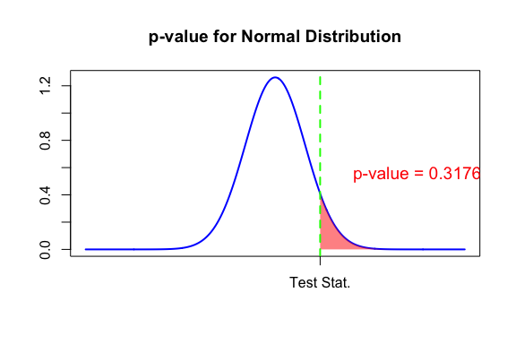

## p-value for one-sided test

$H_0$: $\mu$ = $m$, $H_A$: $\mu$ $\leq$ $m$.

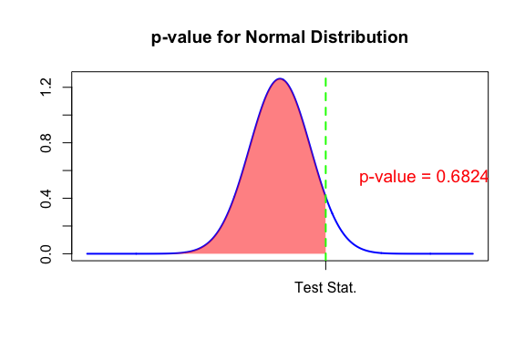

## p-value for two-sided test

$H_0$: $\mu$ = $m$, $H_A$: $\mu$ $\neq$ $m$.

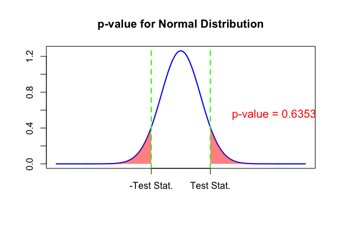

## Testing in $\texttt{R}$

```r
t.test(<vector>, alternative = <alternative>,
       mu = <your_null_assumption>, conf.level = <1 - alpha>)
```

- For two-sided test, <alternative> = “two.sided”.
- For one-sided test, <alternative> = “less” or “greater”, depending on your test.

## Hypothesis Testing: $\texttt{mtcars}$ data

- Let’s test that the average mpg is 18.
- $H_0$: $\mu = 18$ vs $\mu \neq 18$.
- Use $\alpha = 0.05$.
- Here <alternate> = “two.sided” in the $\texttt{R}$ code.

## Example (contd.)

```r
data("mtcars")
MPG = mtcars$mpg
t.test(MPG, alternative = "two.sided",
       mu = 18, conf.level = 0.95)
```

```
##
##  One Sample t-test
##
## data:  MPG
## t = 1.9622, df = 31, p-value = 0.05876
## alternative hypothesis: true mean is not equal to 18
## 95 percent confidence interval:
##  17.91768 22.26357
## sample estimates:
## mean of x
##  20.09062
```

## Hypothesis Testing: $\texttt{mtcars}$ data

**Let’s test that the average mpg is greater than 18. Use $\alpha = 0.05$.**

- $H_0$: ??
- $H_A$: ??
- Here <alternate> = ?? in the $\texttt{R}$ code.

## Hypothesis Testing: $\texttt{mtcars}$ data

**Let’s test that the average mpg is greater than 18. Use $\alpha = 0.05$.**

- $H_0$: $\mu \leq 18$; $H_A$: $\mu > 18$.
- Here <alternate> = “greater” in the $\texttt{R}$ code.

## Example (contd.)

```r
data("mtcars")
MPG = mtcars$mpg
t.test(MPG, alternative = "greater",
       mu = 18, conf.level = 0.95)
```

```
##
##  One Sample t-test
##
## data:  MPG
## t = 1.9622, df = 31, p-value = 0.02938
## alternative hypothesis: true mean is greater than 18
## 95 percent confidence interval:
##  18.28418      Inf
## sample estimates:
## mean of x
##  20.09062
```

## One-Sample Mean Testing

| Test Type | Alternative Hypothesis (H₁) | Test Statistic | Rejection Region | Reject H₀ if |
| --- | --- | --- | --- | --- |
| **Left-Tailed** | $H_A: \mu \leq \mu_0$ | $T = \frac{\bar{x} - \mu_0}{s / \sqrt{n}}$ | $T \leq -t_{\alpha; n-1}$ | p-value $< \alpha$ |
| **Right-Tailed** | $H_A: \mu > \mu_0$ | $T = \frac{\bar{x} - \mu_0}{s / \sqrt{n}}$ | $T \geq t_{\alpha; n-1}$ | p-value $< \alpha$ |
| **Two-Tailed** | $H_A: \mu \neq \mu_0$ | $T = \frac{\bar{x} - \mu_0}{s / \sqrt{n}}$ | $T \geq t_{\alpha/2; n-1} \text{ or } T \leq -t_{\alpha/2; n-1}$ | p-value $< \alpha$ |

## Key Takeaway

- Null hypothesis is assumed true until otherwise proved.
- Fix $\alpha$ = $\mathbb{P}$(Type 1 error) = $\mathbb{P}$(Reject $H_0$ when it is true).
- Minimize $\beta$ = $\mathbb{P}$(Type 2 error) = $\mathbb{P}$(Not reject $H_0$ when it is not true).
- If p-value < $\alpha$, we have evidence to reject $H_0$.
- Otherwise, not enough evidence to reject $H_0$.